# ANOVA/Kruskal-Wallis_R_Code

```r
library(dplyr)
library(dplyr)
library(ggplot2)
library(ggplot2)
library(tidyverse)
library(tidyverse)
library(xlsx)
library(fpp2)
```

```r
str(life_exp)
```

[output not shown]

```r
levels(life_exp$Continent)
```

```
[1] "Africa"        "Asia"          "Europe"        "South America"
```

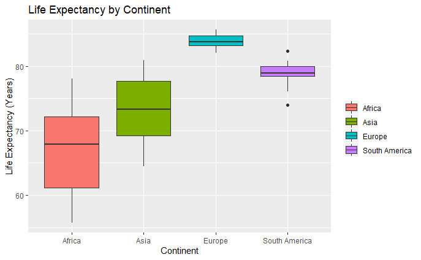

The boxplot shows that the groups do not have equal variance so anova most likely won’t suit this. Will run it anyway and see the results of the levene test for equality of variance.

```r
#One way anova
fit <- aov(Life_expect ~ Continent, data = life_exp)
summary(fit)
```

```
            Df Sum Sq Mean Sq F value   Pr(>F)
Continent    3 1604.9   535.0   21.67 3.43e-08 ***
Residuals   36  888.9    24.7
---
Signif. codes:  0 ‘***’ 0.001 ‘**’ 0.01 ‘*’ 0.05 ‘.’ 0.1 ‘ ’ 1
```

Wil perform some post hoc tests and plot the residual plots and the Q-Q plot

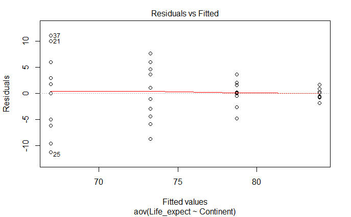

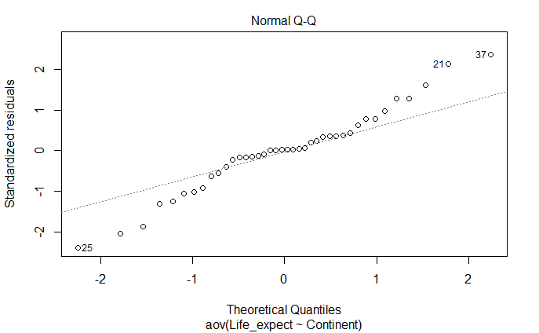

Normal Q-Q plot for the ANOVA clearly shows that the quantities are not normally distributed.

```r
#Shapiro wilk test can also test for normality.
shapiro.test(life_exp$Life_expect)
```

```
    Shapiro-Wilk normality test

data:  life_exp$Life_expect
W = 0.91243, p-value = 0.004486
```

The output of the Shapiro wilk test also shows that the data is not normally distributed.

```r
leveneTest(Life_expect ~ Continent, data = life_exp)
```

```
Levene's Test for Homogeneity of Variance (center = median)
      Df F value    Pr(>F)
group  3  9.7671 7.469e-05 ***
      36
---
Signif. codes:  0 ‘***’ 0.001 ‘**’ 0.01 ‘*’ 0.05 ‘.’ 0.1 ‘ ’ 1
```

The result is not good. Levene test shows that the homoeneity of variances assumption is not met. However, we can still work around this. Can use a Kruskal_Wallis test instead.

Can also use Welch’s adjusted F statistic and the associated p-value (not really because normality assumption is not met).

```r
 welch.test(Life_expect ~ Continent, data = life_exp)
```

```
  Welch's Heteroscedastic F Test (alpha = 0.05)
-------------------------------------------------------------
  data : Life_expect and Continent

  statistic  : 33.62445
  num df     : 3
  denom df   : 17.21984
  p.value    : 2.033183e-07

  Result     : Difference is statistically significant.
-------------------------------------------------------------
```

```r
#One way test with no assumption about variance
kruskal.test(Life_expect ~ Continent, data = life_exp)
```

```
    Kruskal-Wallis rank sum test

data:  Life_expect by Continent
Kruskal-Wallis chi-squared = 29.498, df = 3, p-value = 1.76e-06
```

Can see that the p-value <0.05 shows that there is a statistically significant difference between the continents.

Want to see which pairs of groups are different.

```r
one.way
```

```
### Oneway Anova for y=Life_expect and x=Continent (groups: Africa, Asia, Europe, South America)
```

```
Omega squared: 95% CI = [.4; .74], point estimate = .61
Eta Squared: 95% CI = [.44; .72], point estimate = .64
```

|  | SS | Df | MS | F | p |
| --- | --- | --- | --- | --- | --- |
| Between groups (error + effect) | 1604.88 | 3 | 534.96 | 21.67 | <.001 |
| Within groups (error only) | 888.86 | 36 | 24.69 | NA | NA |

```
### Post hoc test: games-howell
```

|  | diff | ci.lo | ci.hi | t | df | p |
| --- | --- | --- | --- | --- | --- | --- |
| Asia-Africa | 6.32 | -2.35 | 14.99 | 2.09 | 16.09 | .200 |
| Europe-Africa | 17.04 | 9.26 | 24.82 | 6.78 | 9.40 | <.001 |
| South America-Africa | 11.80 | 3.95 | 19.65 | 4.55 | 10.60 | .004 |
| Europe-Asia | 10.72 | 5.27 | 16.17 | 6.04 | 9.82 | .001 |
| South America-Asia | 5.48 | -0.11 | 11.07 | 2.90 | 12.20 | .055 |
| South America-Europe | -5.24 | -7.68 | -2.80 | 6.30 | 13.23 | <.001 |

| Continent | count | mean | sd | median | IQR |
| --- | --- | --- | --- | --- | --- |
| Africa | 10 | 66.95 | 7.857799 | 67.85 | 11.125 |
| Asia | 10 | 73.27 | 5.486357 | 73.30 | 8.400 |
| Europe | 10 | 83.99 | 1.175160 | 83.75 | 1.525 |
| South America | 10 | 78.75 | 2.352894 | 78.90 | 1.550 |